# Real Estate Prediction Platform

Dash Plotly dashboard used for reporting and predicting real state ownerships from Florida, USA.

Datasets are extracted directly from Real Estate agencies.

## Installation

Use the package manager [pip](https://pip.pypa.io/en/stable/) to install all the requirements needed.

```bash
pip install -r requirements.txt
```

## Usage

Go to the folder using terminal and execute

```python
python main.py
```

Then go to the browser and type: 0.0.0.0:8080

## Structure

The project is divided in several files and folders:

Dash_App/

```
|-- app.py

|-- main.py

|-- my_callbacks.py

|-- Tabs/

|-- Resources/

|-- Assets/

|-- requirements.txt

|-- Procfile

|-- README.MD
```

#### main.py

Contains the main programar that starts the execution of the project.

#### app.py

Initialize the app and the server properties

#### my_callbacks.py

Manage all the interactions between the data and the html views contained on the web

#### Tabs/… .py

Contains all the html views and programmatic to displays and capture the data and the behaviour from the user.

#### Resources

Contains all the extra files needed for the running of the application. Most important file is:

#### data_load.py

Contains all the calls to the several Machine Learning algorithmns implemented, XGBM models, recommendation model, data_loads, etc.

#### resources/data_preparation folder

Contains all the scripts for preparing the data and models.

## Screenshots

#### Introduction

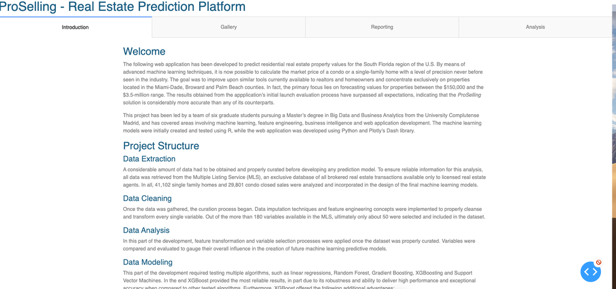

Introduction

#### Gallery

[figure not shown]

Gallery

#### Reporting

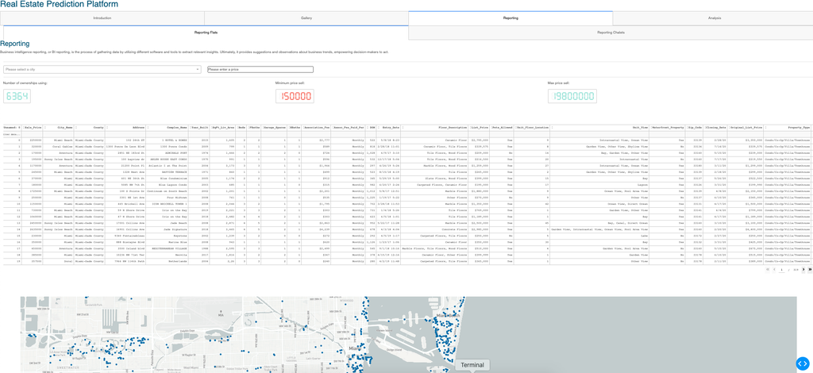

Reporting

#### Analysis

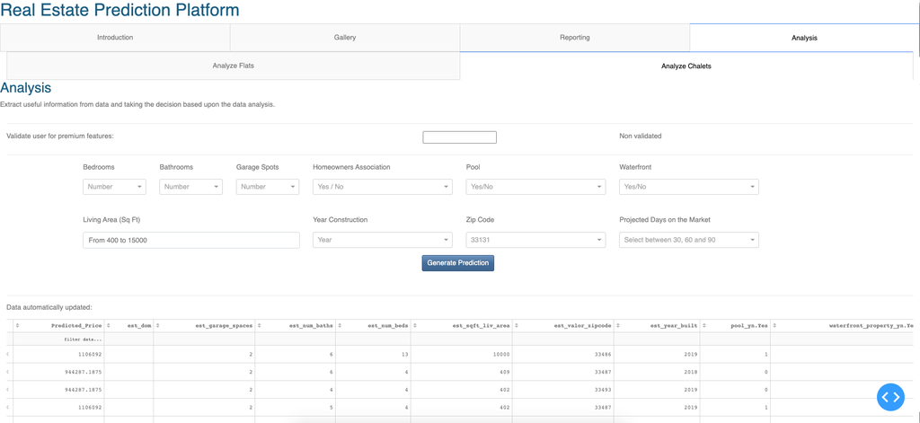

Analysis